# 8a: GARCH model

[Nao Mimoto](https://nmimoto.github.io/) - [Dept. of Statistics](http://www.uakron.edu/stat/) : [The University of Akron](http://www.uakron.edu) [– Class Web Page](https://nmimoto.github.io/477/)

## 1. Stylized Facts of Financial Return

### 1a. Financial (log) Return

$$\begin{align*}
Y_t &= \mbox{ Stock Price (observation) } \\ \\
X_t &= \ln(Y_t) - \ln(Y_{t-1}) \hspace{5mm} : \mbox{ log-return
}
\end{align*}$$

### 1b. Ex: Apple

```r
  library(quantmod)
  source('https://nmimoto.github.io/R/TS-00.txt')

  getSymbols("AAPL")    #- download from Yahoo!
```

```
## [1] "AAPL"
```

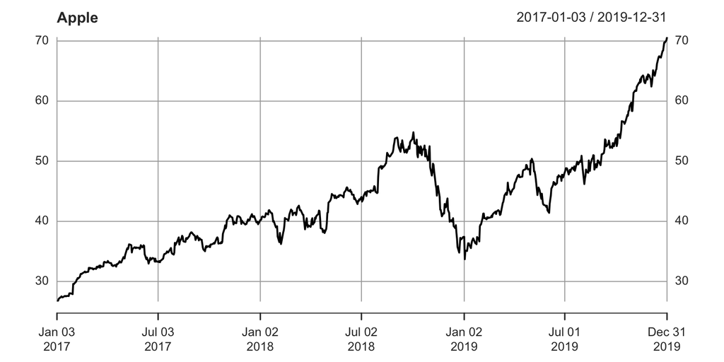

```r
  Apple = Ad(AAPL)['2017::2019']

  plot(Apple)
```

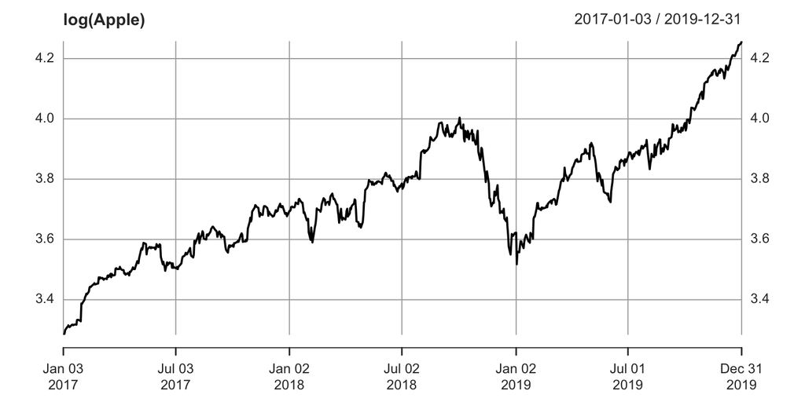

```r
  plot(log(Apple))
```

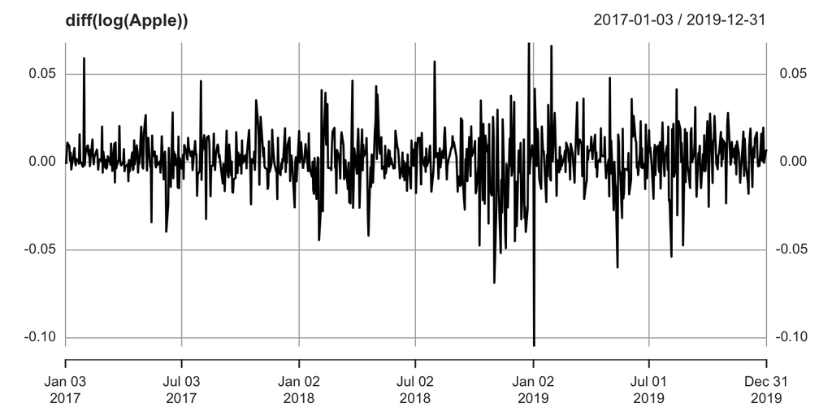

```r
  plot(diff(log(Apple)))
```

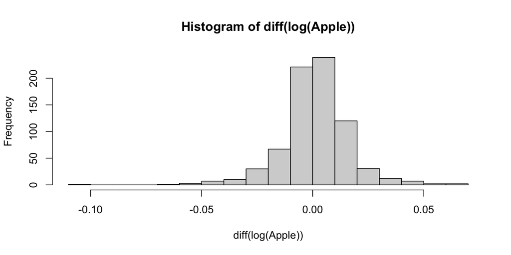

```r
  hist(diff(log(Apple)), 20)
```

### 1c. Stylized Facts

Not normal - Heavy Tailed unconditional and conditional distribution

Uncorrelated

Squares are correlated

Clustering

Asymmetry

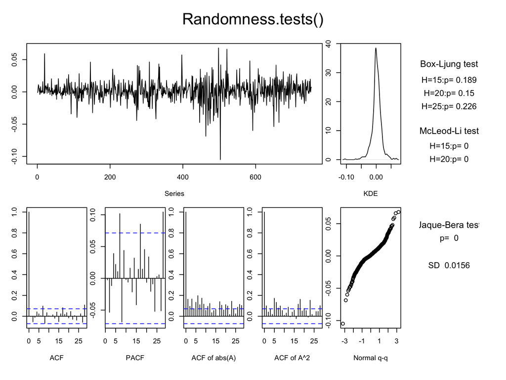

```
##   B-L test H0: the series is uncorrelated
##   M-L test H0: the square of the series is uncorrelated
##   J-B test H0: the series came from Normal distribution
##   SD         : Standard Deviation of the series
```

```
##       BL15 BL20  BL25 ML15 ML20 JB    SD
## [1,] 0.189 0.15 0.226    0    0  0 0.016
```

```r
  Randomness.tests(as.numeric(diff(log(Apple))))
```

### 1d. Ex: SP500

We need a model to capture these characteristics.

```r
  library(quantmod)
  getSymbols("^GSPC")    #- SP500 download from Yahoo!
```

```
## [1] "GSPC"
```

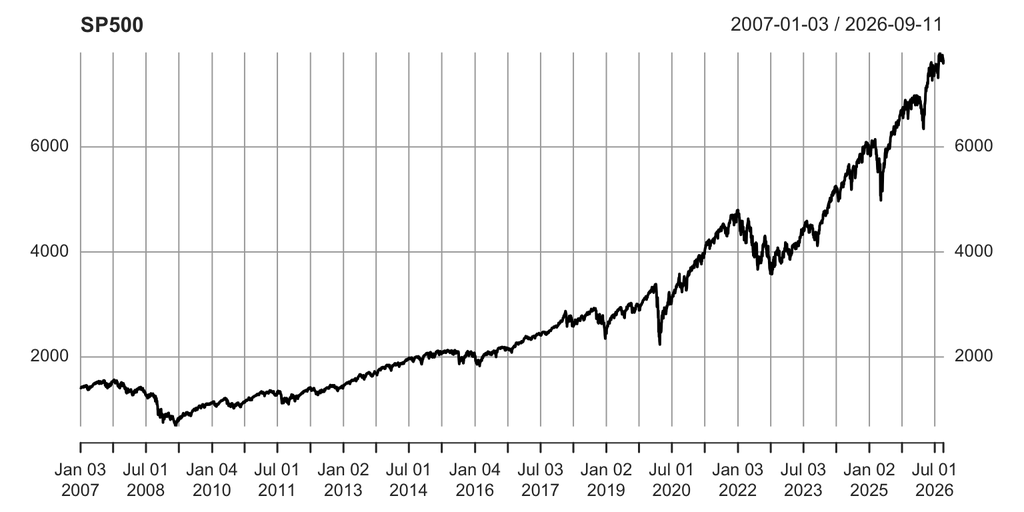

```r
  SP500 = Ad(GSPC)['2000::']

  plot(SP500, type="l")
```

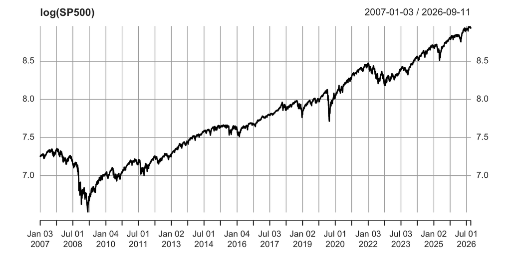

```r
  plot(log(SP500), type="l")
```

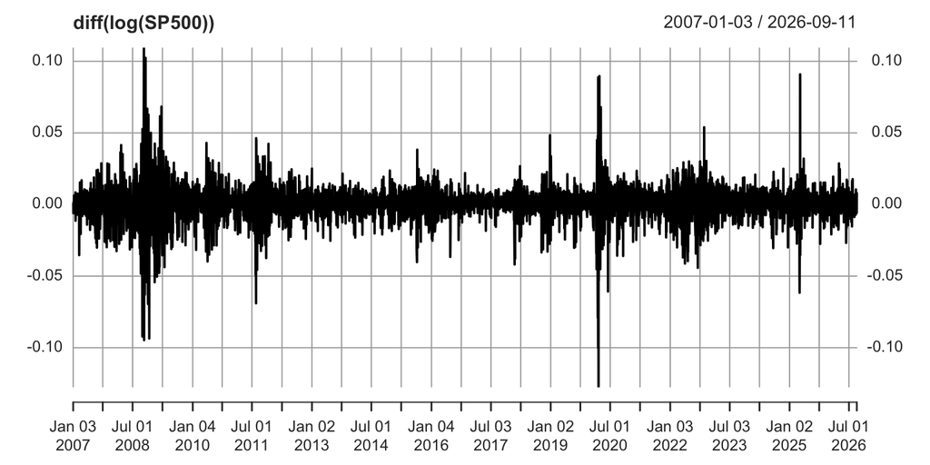

```r
  plot(diff(log(SP500)), type="l")
```

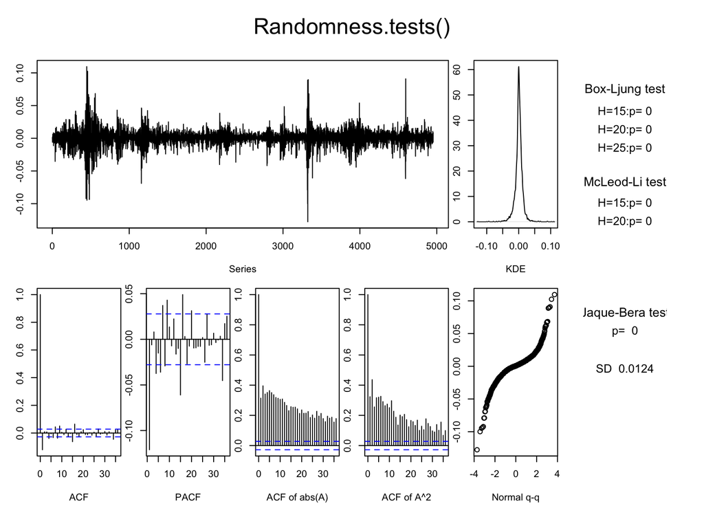

```
##   B-L test H0: the series is uncorrelated
##   M-L test H0: the square of the series is uncorrelated
##   J-B test H0: the series came from Normal distribution
##   SD         : Standard Deviation of the series
```

```
##      BL15 BL20 BL25 ML15 ML20 JB    SD
## [1,]    0    0    0    0    0  0 0.012
```

```r
  Randomness.tests(as.numeric(diff(log(SP500))))
```

## 2. ARCH model

Engle (1985) AutoRegressive Conditionally Heteroscedastic Model

Won Nobel Prize in Economics

$$\begin{align*}
Y_t &= \sigma_t \epsilon_t \hspace{10mm} \epsilon_t \sim_{iid}
N(0,1)
\\\\ \sigma_t^2 &= \omega+ \alpha Y_{t-1}^2
\end{align*}$$

(unconditional) Mean
$$E(Y_t) = \sigma_t E(\epsilon_t) = 0$$

(unconditional) Variance
$$V(Y_t) = \frac{\omega}{1-\alpha} \hspace{5mm} 0<\alpha<1$$

### 2a. Cond’l Mean and Var of ARCH

Conditional mean
$$E[Y_t \Big| Y_{t-1}, \epsilon_{t-1}, \ldots]
\hspace{3mm} = \hspace{3mm} \sigma_t E[\epsilon_t] = 0$$

Conditional variance
$$V[Y_t \Big| Y_{t-1}, \epsilon_{t-1}, \ldots]
\hspace{3mm} = \hspace{3mm} \sigma_t^2 V[\epsilon_t] = \sigma_t^2$$

### 2b. ARCH is uncorrelated

$Y_t$ is uncorrelated, so it will pass the Ljung-Box test.

But $Y_t^2$ is correlated, so it will NOT pass the McLeod-Li test.

### 2c. Cond’l Mean and Var of ARMA

Suppose $Y_t$ is AR(1) series observation

(unconditional) Mean
$$E( Y_t ) = 0$$

(unconditional) Variance
$$V( Y_t ) = \gamma(0) = (1+\phi_1^2) \sigma^2$$

### 2d. Conditional Mean

Conditonal Mean:
$$E\Big(Y_t \hspace{2mm} \Big| \hspace{2mm} \mbox{all variables
realized by yesterday. }\Big)$$

Conditonal mean of AR(1): $Y_t = \phi Y_{t-1} + \epsilon_t$
$$\begin{align*}
E\Big(Y_t \hspace{2mm} \Big| \hspace{2mm} Y_{t-1}, Y_{t-2}, \ldots,
\epsilon_{t-1}, \epsilon_{t-2}, \ldots\Big)
&= E \Big(\phi Y_{t-1} + \epsilon_t \hspace{2mm} \Big|
\hspace{2mm} Y_{t-1}, Y_{t-2}, \ldots, \epsilon_{t-1}, \epsilon_{t-2},
\ldots\Big)\\ \\
&= \phi Y_{t-1} + E(\epsilon_t) \hspace{2mm} = \hspace{2mm} \phi
Y_{t-1}.
\end{align*}$$

Conditonal variance
$$\begin{align*}
V\Big(Y_t \hspace{2mm} \Big| \hspace{2mm} Y_{t-1}, Y_{t-2}, \ldots,
\epsilon_{t-1}, \epsilon_{t-2}, \ldots\Big)
&= V\Big(\phi Y_{t-1} + \epsilon_t \hspace{2mm} \Big|
\hspace{2mm} Y_{t-1}, Y_{t-2}, \ldots, \epsilon_{t-1}, \epsilon_{t-2},
\ldots\Big)\\ \\
&= V(\epsilon_t) \hspace{2mm} = \hspace{2mm} \sigma^2
\end{align*}$$

```r
    n=200
    Y = arima.sim(n = n, list(ar = c(0.8) ))

    v.AR1 = (1+.8^2)*1

    plot(Y, type="o", main="AR(1)", xlim=c(0,n*1.1))
    abline(h=0)
    abline(h=c(1,-1)*1.96*v.AR1, col="red")

    lines(n+1, .8*Y[n], type="p", col="blue")
    lines(c(n+1,n+1), .8*Y[n]+c(1.96,-1.96), type="p", col="red")
```

[output not shown]

Suppose $Y_t$ is MA(1) series observation

(unconditional) Mean
$$E( Y_t ) = 0$$

(unconditional) Variance
$$V( Y_t ) = \gamma(0) = (1+\theta_1^2) \sigma^2$$

Conditonal mean of MA(1): $Y_t = \epsilon_t + \theta_1 \epsilon_{t-1}$
$$\begin{align*}
E\Big(Y_t \hspace{2mm} \Big| \hspace{2mm} Y_{t-1}, Y_{t-2}, \ldots,
\epsilon_{t-1}, \epsilon_{t-2}, \ldots\Big)
&= E \Big( \epsilon_t + \theta_1 \epsilon_{t-1} \hspace{2mm} \Big|
\hspace{2mm} Y_{t-1}, Y_{t-2}, \ldots, \epsilon_{t-1}, \epsilon_{t-2},
\ldots\Big) \\\\
&= E ( \epsilon_t )+ \theta_1 \epsilon_{t-1} \hspace{2mm} =
\hspace{2mm} \theta_1 \epsilon_{t-1}
\end{align*}$$

Note that $\epsilon_{t-1}$ is not observable.

AR(1)
$$\begin{align*}
\mbox{ Uncond'l } \hspace{20mm} \mbox{ cond'l } \\
E(Y_t) &= 0, \hspace{28mm} E(Y_t|\omega_{t-1}) = \phi_1
Y_{t-1}, \\
Var(Y_t) &= (1+\phi_1^2)\sigma^2 \hspace{10mm}
Var(Y_t|\omega_{t-1}) = \sigma^2
\end{align*}$$

MA(1)
$$\begin{align*}
\mbox{ Uncond'l } \hspace{20mm} \mbox{ cond'l } \\
E(Y_t) &= 0, \hspace{28mm} E(Y_t|\omega_{t-1}) = \theta_1
\epsilon_{t-1}, \\
Var(Y_t) &= (1+\theta_1^2)\sigma^2 \hspace{10mm}
Var(Y_t|\omega_{t-1}) = \sigma^2
\end{align*}$$

For ARMA(p,q) model, conditional mean changes, but conditional variance is constant.

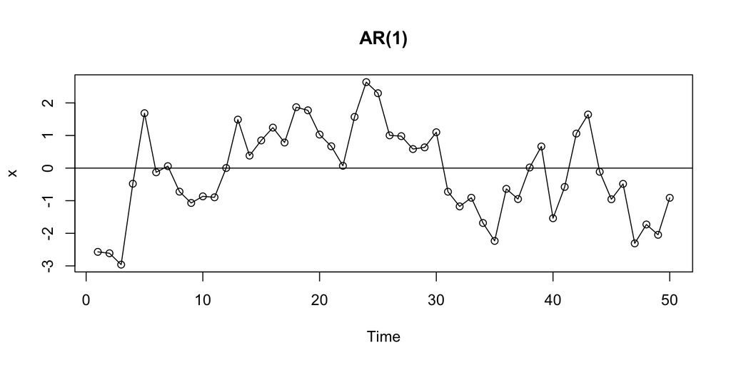

```r
  x  = arima.sim(n = 50, list(ar = c(0.8) ))
  plot(x, type="o", main="AR(1)")
  abline(h=0)
```

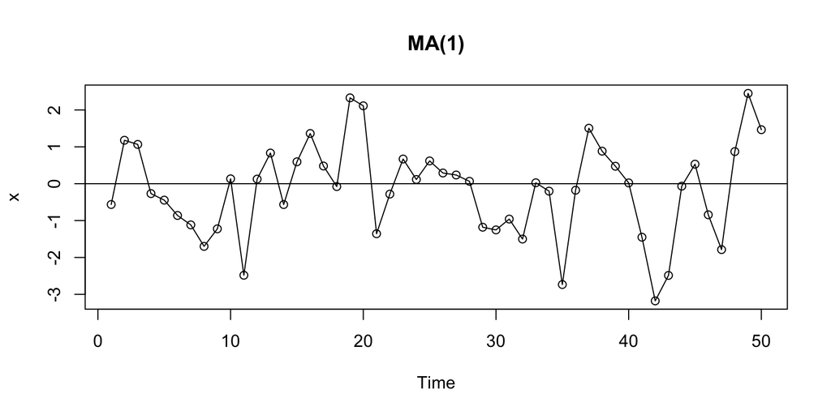

```r
  x  = arima.sim(n = 50, list(ma = c(0.5) ))
  plot(x, type="o", main="MA(1)")
  abline(h=0)
```

### 2e. Heteroschedasticity

Don’t confuse the conditional heteroscedasticity with (unconditonal) heteroscedasticity:

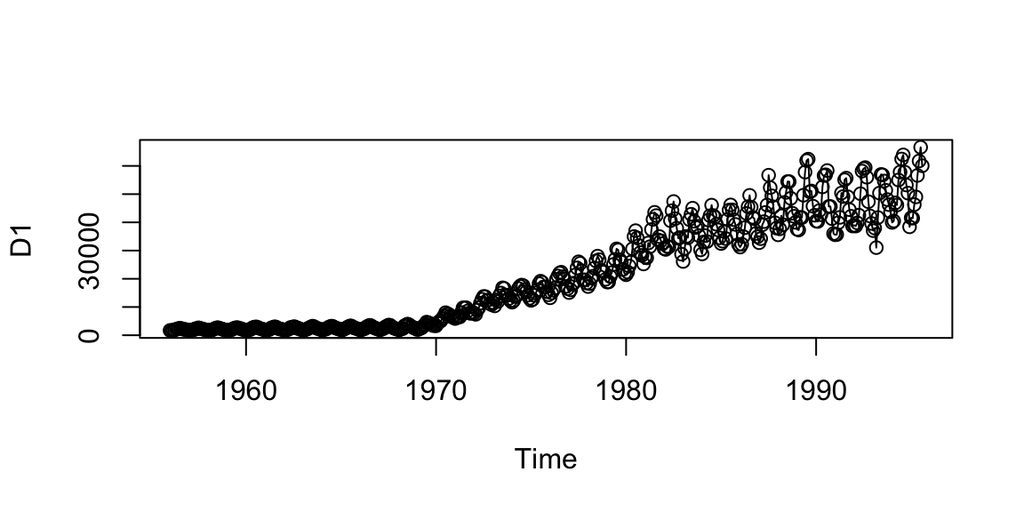

```r
  D = read.csv("https://nmimoto.github.io/datasets/gas.csv")
  D1 = ts(D[,2], start=c(1956, 1), freq=12)
  plot(D1, type='o')
```

## 3. GARCH model

GARCH(1,1) model

$$\begin{align*}
Y_t &= \sigma_t \epsilon_t \hspace{10mm} \epsilon_t \sim_{iid}
N(0,1) \\\\
\sigma_t^2 &= \omega + \alpha Y_{t-1}^2 + \beta \sigma^2_{t-1}
\end{align*}$$

### 3a. Conditional Mean and Var of GARCH

Conditional Mean: $0$

Conditional Variance : $\sigma_t^2$

### 3b. Ex: Daily SPY

```r
  library(quantmod)
  source('https://nmimoto.github.io/R/TS-00.txt')

  getSymbols("SPY")    #- SP500 download from Yahoo!
```

```
## [1] "SPY"
```

```r
  SPY = Ad(SPY)['2010::']

  is.ts(SPY)      # not ts object
```

```
## [1] FALSE
```

```r
  is.xts(SPY)     # its xts object
```

```
## [1] TRUE
```

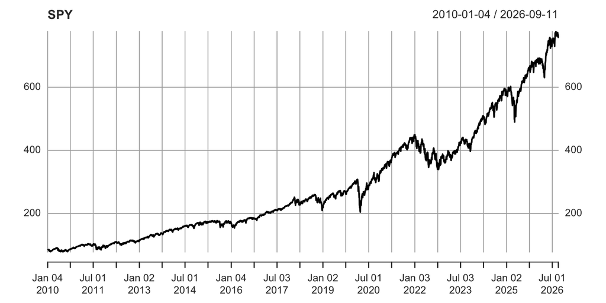

```r
  plot( SPY )
```

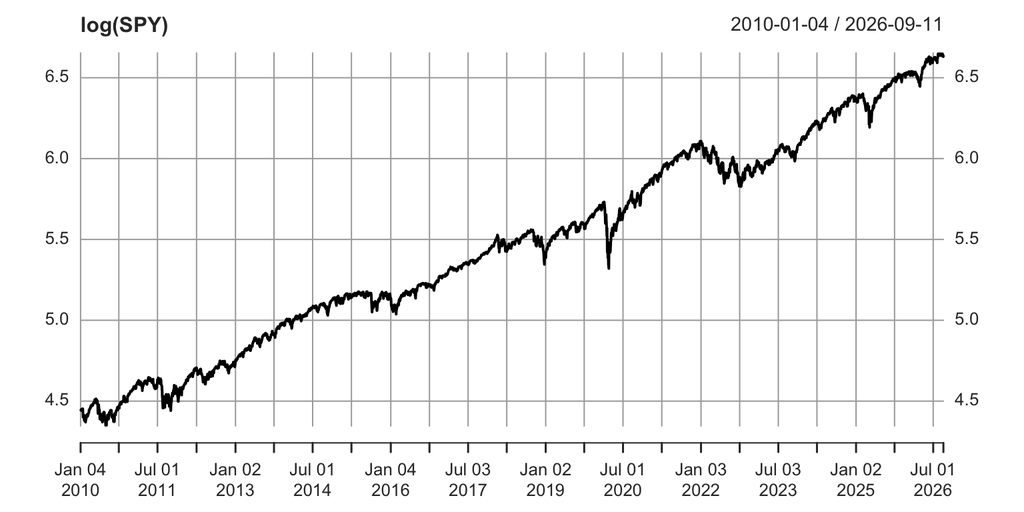

```r
  plot( log(SPY) )
```

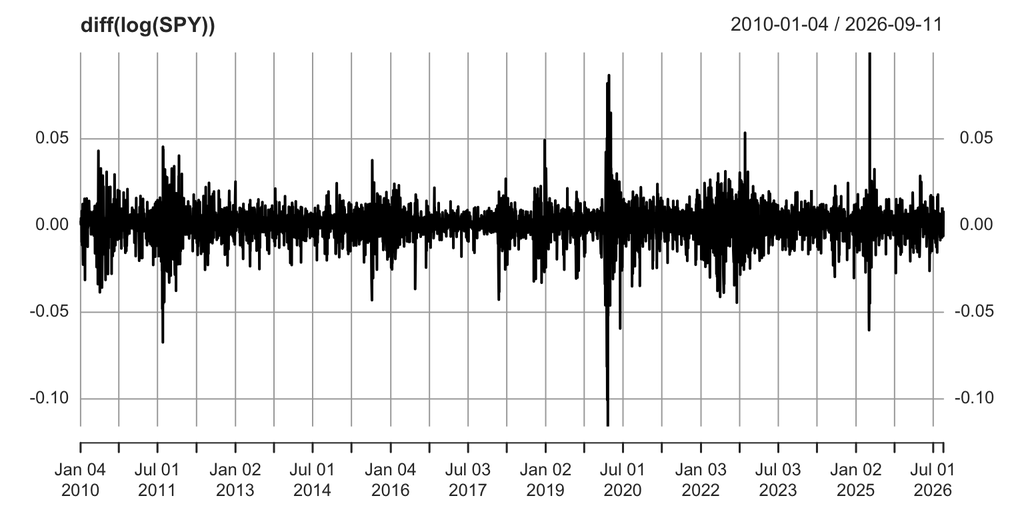

```r
  plot( diff( log(SPY) ) )
```

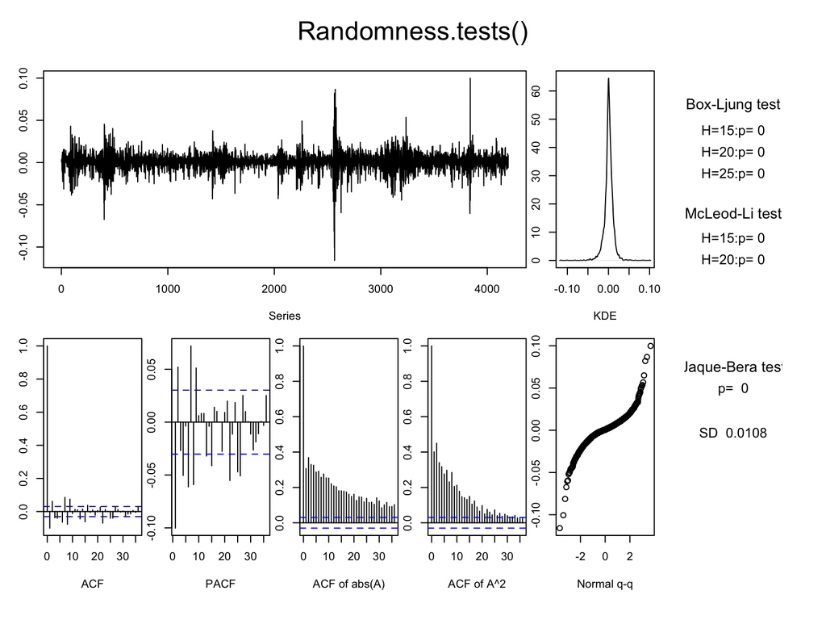

```
##   B-L test H0: the series is uncorrelated
##   M-L test H0: the square of the series is uncorrelated
##   J-B test H0: the series came from Normal distribution
##   SD         : Standard Deviation of the series
```

```
##      BL15 BL20 BL25 ML15 ML20 JB    SD
## [1,]    0    0    0    0    0  0 0.011
```

```r
  Randomness.tests( diff(log(SPY)) )
```

```r
  # Fit GARCH model
  library(fGarch)
  Y = diff( log(SPY) )[-1]     # remove the first diff for NA

    Fit01 =  garchFit(~ garch(1,1), data=Y, cond.dist="norm", include.mean = FALSE, trace = FALSE)
    Fit01
```

```
##
## Title:
##  GARCH Modelling
##
## Call:
##  garchFit(formula = ~garch(1, 1), data = Y, cond.dist = "norm",
##     include.mean = FALSE, trace = FALSE)
##
## Mean and Variance Equation:
##  data ~ garch(1, 1)
## <environment: 0x10e015468>
##  [data = Y]
##
## Conditional Distribution:
##  norm
##
## Coefficient(s):
##      omega      alpha1       beta1
## 3.7798e-06  1.5098e-01  8.1387e-01
##
## Std. Errors:
##  based on Hessian
##
## Error Analysis:
##         Estimate  Std. Error  t value Pr(>|t|)
## omega  3.780e-06   4.755e-07    7.949 1.78e-15 ***
## alpha1 1.510e-01   1.290e-02   11.703  < 2e-16 ***
## beta1  8.139e-01   1.396e-02   58.291  < 2e-16 ***
## ---
## Signif. codes:  0 '***' 0.001 '**' 0.01 '*' 0.05 '.' 0.1 ' ' 1
##
## Log Likelihood:
##  13917.88    normalized:  3.316149
##
## Description:
##  Sat Sep 12 23:10:40 2026 by user:
```

```r
    ##  Fit01@fit$par                  # estimated parameters
    ##  Fit01@residuals                # this is not GARCH residuals! This is same as Y.
    ##  Fit01@sigma.t                  # estimated sig_t
    ##  Fit01@residuals/Fit1@sigma.t   # this is the (standardized) GARCH residuals

    Fit01@fit$ics                   # AIC and BIC are here
```

```
##       AIC       BIC       SIC      HQIC
## -6.630869 -6.626336 -6.630870 -6.629266
```

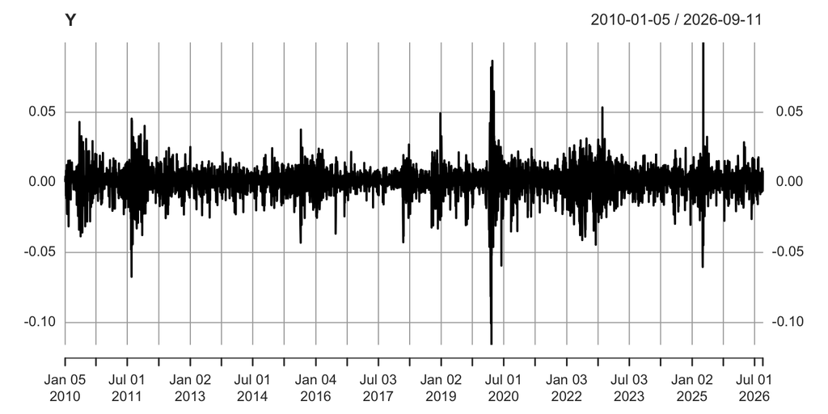

```r
    plot(Y)
```

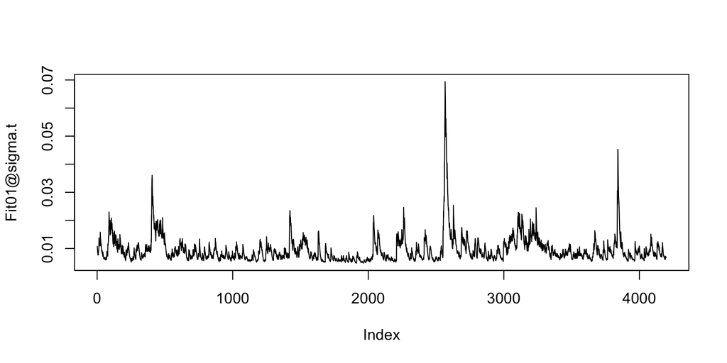

```r
    plot(Fit01@sigma.t, type="l")   # estimated Sigma_t
```

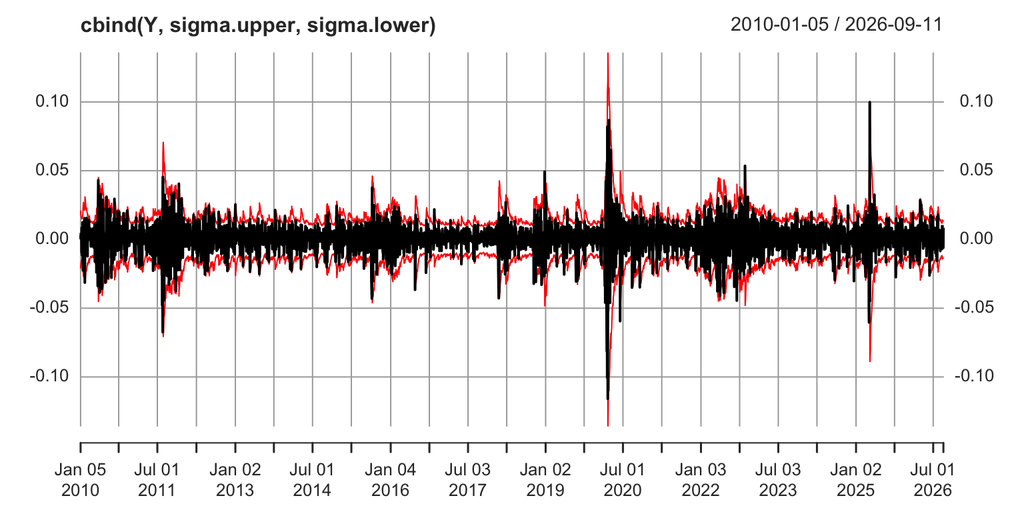

```r
    sigma.upper = xts(1.96*Fit01@sigma.t, order.by=index(Y))
    sigma.lower = xts(-1.96*Fit01@sigma.t, order.by=index(Y))

    plot( cbind(Y, sigma.upper, sigma.lower),
        col=c("black", "red", "red"), lwd=c(2,1,1) )
```

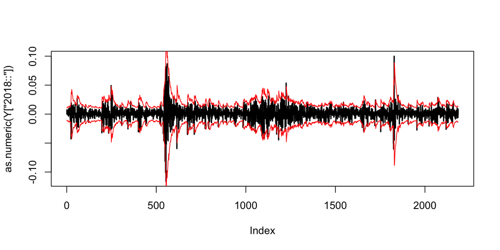

```r
    plot(  as.numeric(          Y["2018::"]), type="h", lwd=2)
    lines( as.numeric(sigma.upper["2018::"]), col="red")
    lines( as.numeric(sigma.lower["2018::"]), col="red")
```

GARCH(1,1) model

$$\begin{align*}
Y_t &= \sigma_t \epsilon_t \hspace{10mm} \epsilon_t \sim_{iid}
N(0,1) \\\\
\sigma_t^2 &= \omega + \alpha Y_{t-1}^2 + \beta \sigma^2_{t-1}
\end{align*}$$

standardized residuals

$$\begin{align*}
\hat \sigma_t^2 &= \hat \omega + \hat \alpha Y_{t-1}^2 + \hat
\beta \sigma^2_{t-1}
\\ \\ \hat \epsilon_t &= \frac{Yt}{\hat \sigma}
\end{align*}$$

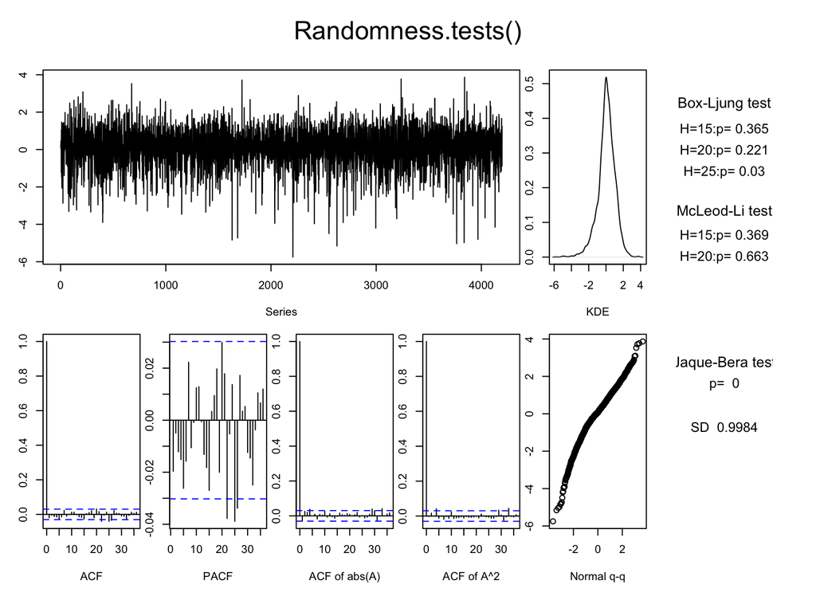

```
##   B-L test H0: the series is uncorrelated
##   M-L test H0: the square of the series is uncorrelated
##   J-B test H0: the series came from Normal distribution
##   SD         : Standard Deviation of the series
```

```
##       BL15  BL20 BL25  ML15  ML20 JB    SD
## [1,] 0.365 0.221 0.03 0.369 0.663  0 0.998
```

```r
    res1  = Y/Fit01@sigma.t        #- this is GARCH residuals
    Randomness.tests(res1)
```